# Rentals_prediction_Divvy

## Introduction

The bike-sharing industry has experienced continuous growth in recent years, with one of its key performance indicators being the average revenue per user (ARPU). This metric reflects the average annual revenue generated by a user, with revenue typically represented by the total booking volume. By 2027, the U.S. is expected to lead globally in ARPU, with an estimated average of $72 USD. Several macroeconomic factors, such as urbanization and population growth, have driven the demand for sustainable transportation options. Government initiatives and sustainable policies have been crucial in fostering the growth of the bike rental industry. Many countries have supported this trend by providing public infrastructure, such as bike lanes and parking facilities, to encourage the adoption of sustainable transportation.

The primary objective of this project is to predict the number of bike rentals for Dyyv, a leading company based in Chicago, over a 30-day period. By accurately forecasting rental volumes, the company can optimize operations, enhance service offerings, and contribute to the broader goal of promoting sustainable urban mobility.

## Data Preparation

### Imports and Data Check

```python
#!################################!#
#!# importing required libraries #!#
#!################################!#

# core libraries
import numpy as np                                  # Mathematical essentials
import pandas as pd                                 # Data science essentials

# machine Learning libraries
from sklearn.model_selection import train_test_split   # Train/test split
from sklearn.linear_model import SGDRegressor          # Stochastic Gradient Descent Regressor
from sklearn.linear_model import LinearRegression      # Linear Regression
from sklearn.impute import KNNImputer                  # K-Nearest Neighbors Imputer
from sklearn.neighbors import KNeighborsRegressor      # KNN for regression
from sklearn.preprocessing import StandardScaler       # Feature scaling
from sklearn.tree import DecisionTreeRegressor         # Decision tree for regression
from sklearn.ensemble import RandomForestRegressor     # Random Forest for regression
from sklearn.ensemble import GradientBoostingRegressor # Gradient Boosting for regression
from sklearn.model_selection import RandomizedSearchCV, GridSearchCV, KFold # Hyperparameter tuning and cross-validation
from sklearn.metrics import mean_squared_error         # Performance metrics
from sklearn.preprocessing import OneHotEncoder        # One-hot encoding for categorical features
from sklearn.tree import plot_tree                     # Plot decision trees

# ddditional libraries
import seaborn as sns                                                      # Enhanced data visualization
import statsmodels.formula.api as smf                                      # Linear modeling using formulas
import matplotlib.pyplot as plt                                            # Data visualization
from scipy.stats import yeojohnson                                         # Transformation for normalizing data
from statsmodels.stats.outliers_influence import variance_inflation_factor # Calculate VIF for multicollinearity
from statsmodels.tools.tools import add_constant                           # Add constant term for regression models
import warnings                                                            # Handle warnings
from matplotlib.ticker import FuncFormatter                                # Custom formatting for matplotlib tick labels

#!################################!#
#!# setting pandas print options #!#
#!################################!#

pd.set_option('display.max_rows', 500)
pd.set_option('display.max_columns', 500)
pd.set_option('display.width', 1000)
```

```python
## importing data ##

# reading modeling data into Python
modeling_data = '/Users/brunotg/Downloads/Computational Data Analytics with Python/Assignments/Chicago Bikes Regression Project/train.xlsx'


# calling this dataframe df_train
df_train = pd.read_excel(io         = modeling_data,
                         sheet_name = 'data',
                         header     = 0,
                         index_col  = 'ID')



# reading testing data into Python
testing_data = '/Users/brunotg/Downloads/Computational Data Analytics with Python/Assignments/Chicago Bikes Regression Project/test.xlsx'

# calling this dataframe df_test
df_test = pd.read_excel(io         = testing_data,
                        sheet_name = 'data',
                        header     = 0,
                        index_col  = 'ID')
```

```python
# concatenating datasets together for exploratory data analysis
df_train['set'] = 'Not Kaggle'
df_test ['set'] = 'Kaggle'

# concatenating both datasets together for general view
df_full = pd.concat(objs         = [df_train, df_test],
                    axis         = 0,
                       ignore_index = False)


# checking data
df_full.head(n = 5)
```

| ID | DateHour | Temperature(F) | Humidity(%) | Wind speed (mph) | Visibility(miles) | DewPointTemperature(F) | Rainfall(in) | Snowfall(in) | SolarRadiation(MJ/m2) | Holiday | FunctioningDay | RENTALS | set |
| --- | --- | --- | --- | --- | --- | --- | --- | --- | --- | --- | --- | --- | --- |
| mb_1039 | 2023-10-14 05:59:54.810000 | 52 | 81 | 0.4 | 2.9 | 46.4 | 0.0 | 0.0 | 0.00 | No | Yes | 519.0 | Not Kaggle |
| mb_1330 | 2023-10-26 08:59:53.355000 | 51 | 53 | 2.2 | NaN | 35.2 | 0.0 | 0.0 | 1.01 | No | Yes | 1251.0 | Not Kaggle |
| mb_551 | 2023-09-23 21:59:57.250000 | 56 | 49 | 2.5 | 3.4 | 38.8 | 0.0 | 0.0 | 0.00 | No | Yes | 1685.0 | Not Kaggle |
| mb_2103 | 2023-12-19 14:00:00 | 69 | 32 | 9.8 | 12.4 | 38.7 | 0.0 | 0.0 | 2.36 | No | No | 0.0 | Not Kaggle |
| mb_1430 | 2023-10-30 12:59:52.855000 | 53 | 20 | 2.9 | 10.8 | 12.9 | 0.0 | 0.0 | 1.96 | No | Yes | 814.0 | Not Kaggle |

## Exploratory Data Analysis (EDA)

```python
# formatting and printing the dimensions of the dataset
print(f"""
Size of Original Dataset
------------------------
Observations (rows): {df_full.shape[0]}
Features (columns) : {df_full.shape[1]}
""")
```

```
Size of Original Dataset
------------------------
Observations (rows): 2184
Features (columns) : 13
```

```python
# checking dataset structure
df_full.info()
```

```
<class 'pandas.core.frame.DataFrame'>
Index: 2184 entries, mb_1039 to mb_1225
Data columns (total 13 columns):
 #   Column                  Non-Null Count  Dtype
---  ------                  --------------  -----
 0   DateHour                2184 non-null   object
 1   Temperature(F)          2184 non-null   int64
 2   Humidity(%)             2184 non-null   int64
 3   Wind speed (mph)        2184 non-null   float64
 4   Visibility(miles)       2108 non-null   float64
 5   DewPointTemperature(F)  2117 non-null   float64
 6   Rainfall(in)            2184 non-null   float64
 7   Snowfall(in)            2184 non-null   float64
 8   SolarRadiation(MJ/m2)   2078 non-null   float64
 9   Holiday                 2184 non-null   object
 10  FunctioningDay          2184 non-null   object
 11  RENTALS                 1638 non-null   float64
 12  set                     2184 non-null   object
dtypes: float64(7), int64(2), object(4)
memory usage: 238.9+ KB
```

```python
# checking summary statistics of dataset
df_full.describe().round(2)
```

|  | Temperature(F) | Humidity(%) | Wind speed (mph) | Visibility(miles) | DewPointTemperature(F) | Rainfall(in) | Snowfall(in) | SolarRadiation(MJ/m2) | RENTALS |
| --- | --- | --- | --- | --- | --- | --- | --- | --- | --- |
| count | 2184.00 | 2184.00 | 2184.00 | 2108.00 | 2117.00 | 2184.00 | 2184.00 | 2078.00 | 1638.00 |
| mean | 57.39 | 59.23 | 3.34 | 9.65 | 42.04 | 0.00 | 0.00 | 0.55 | 828.15 |
| std | 12.86 | 18.69 | 2.07 | 3.49 | 14.00 | 0.04 | 0.02 | 0.81 | 657.60 |
| min | 26.00 | 13.00 | 0.00 | 0.00 | -2.20 | 0.00 | 0.00 | 0.00 | 0.00 |
| 25% | 48.00 | 44.00 | 1.80 | 7.40 | 33.40 | 0.00 | 0.00 | 0.00 | 241.50 |
| 50% | 57.00 | 59.00 | 2.90 | 11.70 | 41.90 | 0.00 | 0.00 | 0.00 | 761.50 |
| 75% | 68.00 | 74.00 | 4.50 | 12.40 | 51.60 | 0.00 | 0.00 | 0.98 | 1203.75 |
| max | 91.00 | 97.00 | 12.80 | 12.40 | 75.00 | 0.71 | 0.30 | 3.18 | 3303.00 |

Based on the summary statistics, it is evident that several variables exhibit significant skewness, indicating that the data is heavily concentrated on one tail of the distribution. The standard deviation is notably high for Humidity (%) at 18.69, indicating the highest variability among the features. Similarly, Temperature (F), Wind Speed (mph), and Dew Point Temperature (F) exhibit moderate variability, with standard deviations of 12.86°F, 2.07 mph, and 14.00°F, respectively.

### Correlation Analysis

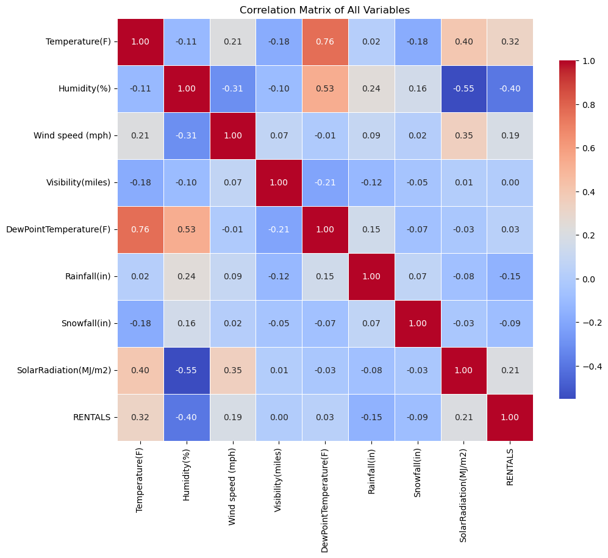

```python
rentals_corr = df_full.corr(method       = 'pearson',
                            numeric_only = True)
# Build and adjust the heatmap
plt.figure(figsize = (11, 9))

sns.heatmap(rentals_corr,
            annot      = True,
            fmt        = ".2f",
            cmap       = "coolwarm",
            cbar_kws   = {'shrink': .8},
            linewidths = 0.5)

# Set the title for the heatmap
plt.title('Correlation Matrix of All Variables')

# Show the plot
plt.show()
```

For the negatively correlated variables with the most significant correlations, Humidity(%) has the highest negative correlation of (-.40). This indicates that people are less likely to rent bikes as humidity levels increase, potentially due to the discomfort of riding in such conditions. Rainfall(in) has the second most significant negative correlation with (-.15), suggesting that people are surprisingly more inclined to rent bikes when it is raining compared to when humidity levels increase.

```python
# pearson correlation for RENTALS
rentals_corr = df_full.corr(method       = 'pearson',
                            numeric_only = True).round(decimals = 4)


# checking results
print(f"""
Correlations with Rentals
---------------------------
{rentals_corr.loc[ : , 'RENTALS' ].sort_values(ascending = False)}
""")
```

```
Correlations with Rentals
---------------------------
RENTALS                   1.0000
Temperature(F)            0.3228
SolarRadiation(MJ/m2)     0.2075
Wind speed (mph)          0.1863
DewPointTemperature(F)    0.0309
Visibility(miles)         0.0044
Snowfall(in)             -0.0869
Rainfall(in)             -0.1458
Humidity(%)              -0.3953
Name: RENTALS, dtype: float64
```

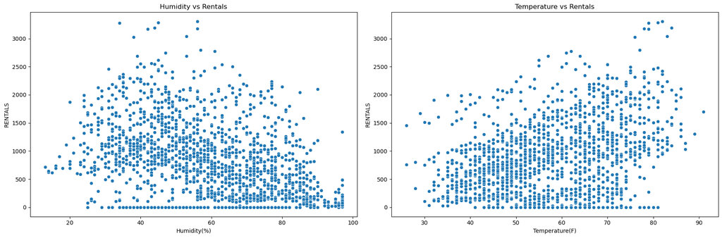

```python
# create a figure with two subplots
fig, axes = plt.subplots(1, 2, figsize = (18, 6))

# scatterplot for Humidity vs RENTALS
sns.scatterplot(x    = 'Humidity(%)',
                y    = 'RENTALS',
                data = df_full,
                ax   = axes[0])

axes[0].set_title('Humidity vs Rentals')

# scatterplot for Temperature vs RENTALS
sns.scatterplot(x    = 'Temperature(F)',
                y    = 'RENTALS',
                data = df_full,
                ax   = axes[1])

axes[1].set_title('Temperature vs Rentals')

# show the plots
plt.tight_layout()
plt.show()
```

For humidity, there is a medium negative correlation. Most observations range from 20% to 90%, with a higher density from 30% to 80%, several outliers are present in medium humidity levels, with more than 2500 rentals per day. This may be due to special events or exceptional days, as humidity increases, rentals tend to decrease, especially beyond 90%, when rentals tend to be below 500, however, some outliers are reaching more than 1000 rentals per day.

For temperature (F), most observations fall within the 30°F to 80°F range, showing a medium positive correlation. However, when the temperature reaches 80°F, a significant increase in rentals is notable, ranging from 1000 to 3000 per day, which can be considered as exeptional days. This confirms that as the temperature increases, there is a higher likelihood of people renting bikes due to favorable weather conditions.

## Missing Value Imputation

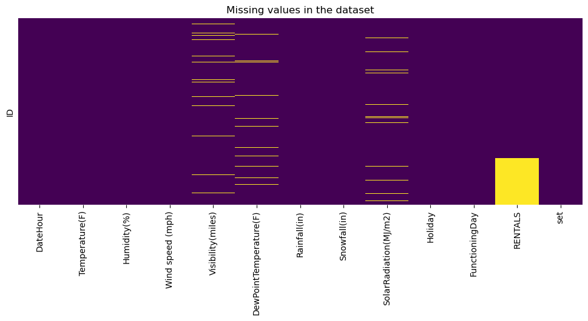

```python
# sizing the plot
plt.figure(figsize      = (12,4))

# creating the heatmap to show missing values
sns.heatmap(df_full.isnull(),
            cbar        = False,
            cmap        = 'viridis',
            yticklabels = False)

# showing the plot
plt.title('Missing values in the dataset');
```

Visibility(miles), DewPointTemperature(F) and SolarRadiation(MJ/m2) are the variables containing missing values that will be imputed, Rentals is the target variable and the missing values are the ones to predict. It's important to separate the datasets to impute the missing values to prevent bias in the model, failing to do so can lead to data leakage, where information from the target variable influences the imputation process.

```python
# checking each feature for missing values
df_full.isnull().sum(axis = 0)
```

```
DateHour                    0
Temperature(F)              0
Humidity(%)                 0
Wind speed (mph)            0
Visibility(miles)          76
DewPointTemperature(F)     67
Rainfall(in)                0
Snowfall(in)                0
SolarRadiation(MJ/m2)     106
Holiday                     0
FunctioningDay              0
RENTALS                   546
set                         0
dtype: int64
```

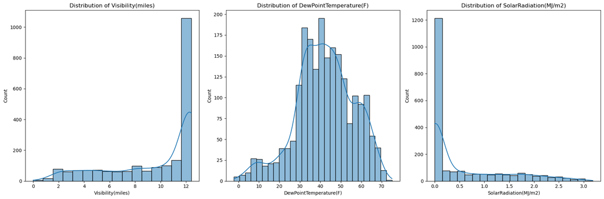

```python
# set the figure size
plt.figure(figsize = (18, 6))

# first plot
plt.subplot(1, 3, 1)
sns.histplot(data = df_full,
             x    = 'Visibility(miles)',
             kde  = True)

# title and labels
plt.title("Distribution of Visibility(miles)")
plt.xlabel("Visibility(miles)")
plt.ylabel("Count")

# second plot
plt.subplot(1, 3, 2)
sns.histplot(data = df_full,
             x    = 'DewPointTemperature(F)',
             kde  = True)

plt.title("Distribution of DewPointTemperature(F)")
plt.xlabel("DewPointTemperature(F)")
plt.ylabel("Count")

# third plot
plt.subplot(1, 3, 3)
sns.histplot(data = df_full,
             x    = 'SolarRadiation(MJ/m2)',
             kde  = True)

# title and labels
plt.title("Distribution of SolarRadiation(MJ/m2)")
plt.xlabel("SolarRadiation(MJ/m2)")
plt.ylabel("Count")

# adjust the layout and display the plot
plt.tight_layout()
plt.show()
```

When dealing with missing values in variables, it's important to analyze their distribution. Visibility (miles) and Solar Radiation (MJ/m2) show strong skewness, indicating that a significant number of values are concentrated at one extreme. On the other hand, Dew Point Temperature (F) has a more symmetric distribution, and it's crucial to preserve a similar distribution and mean/median of the variables while dealing with missing values to maintain data integrity and ensure a realistic interpretation of the model. To achieve this, an advanced imputation technique like KNN will be applied. This method aims to preserve the integrity of the data while imputing missing values.

```python
# checking missing values for the train and test sets
missing_values_train = df_train.isnull().sum(axis=0)
missing_values_test = df_test.isnull().sum(axis=0)

# combining the results into a DataFrame
missing_values_combined = pd.DataFrame({
    'Train Set': missing_values_train,
    'Test Set': missing_values_test
})

# displaying the combined DataFrame
missing_values_combined
```

|  | Train Set | Test Set |
| --- | --- | --- |
| DateHour | 0 | 0.0 |
| DewPointTemperature(F) | 51 | 16.0 |
| FunctioningDay | 0 | 0.0 |
| Holiday | 0 | 0.0 |
| Humidity(%) | 0 | 0.0 |
| RENTALS | 0 | NaN |
| Rainfall(in) | 0 | 0.0 |
| Snowfall(in) | 0 | 0.0 |
| SolarRadiation(MJ/m2) | 80 | 26.0 |
| Temperature(F) | 0 | 0.0 |
| Visibility(miles) | 63 | 13.0 |
| Wind speed (mph) | 0 | 0.0 |
| set | 0 | 0.0 |

```python
# subset containing only columns with missing values
cols_with_mv = ['Visibility(miles)', 'DewPointTemperature(F)', 'SolarRadiation(MJ/m2)']

# imputing missing values using KNN imputer
imputer = KNNImputer(n_neighbors = 5)
df_train[cols_with_mv] = imputer.fit_transform(df_train[cols_with_mv])
df_test [cols_with_mv] = imputer.fit_transform(df_test[cols_with_mv])

# checking missing values for the train and test sets
missing_values_train = df_train.isnull().sum(axis=0)
missing_values_test = df_test.isnull().sum(axis=0)

# combining the results into a DataFrame
missing_values_imputed = pd.DataFrame({
    'Train Set': missing_values_train,
    'Test Set': missing_values_test
})

# checking results of imputation
missing_values_imputed
```

|  | Train Set | Test Set |
| --- | --- | --- |
| DateHour | 0 | 0.0 |
| DewPointTemperature(F) | 0 | 0.0 |
| FunctioningDay | 0 | 0.0 |
| Holiday | 0 | 0.0 |
| Humidity(%) | 0 | 0.0 |
| RENTALS | 0 | NaN |
| Rainfall(in) | 0 | 0.0 |
| Snowfall(in) | 0 | 0.0 |
| SolarRadiation(MJ/m2) | 0 | 0.0 |
| Temperature(F) | 0 | 0.0 |
| Visibility(miles) | 0 | 0.0 |
| Wind speed (mph) | 0 | 0.0 |
| set | 0 | 0.0 |

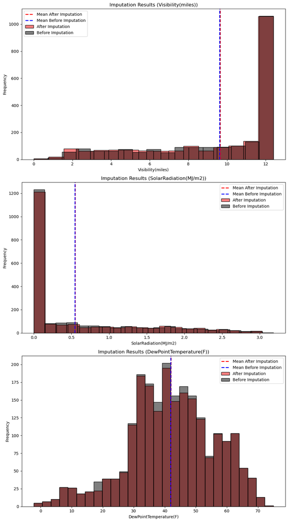

```python
# creating a new DataFrame to visualize the change of distribution after imputation
df_full_imputed = pd.concat(objs         = [df_train, df_test],
                            axis         = 0,
                            ignore_index = False)

# formating the subplots
fig, axes = plt.subplots(nrows   = 3,
                         ncols   = 1,
                         figsize = (10, 18))

# subplot 1: Visibility(miles)
sns.histplot(data  = df_full,
             x     = 'Visibility(miles)',
             fill  = True,
             color = 'red',
             ax    = axes[0],
             alpha = 0.5,
             label = 'After Imputation')

# creating the histplot with the new DataFrame
sns.histplot(data  = df_full_imputed,
             x     = 'Visibility(miles)',
             fill  = True, color = 'black',
             ax    = axes[0],
             alpha = 0.5,
             label = 'Before Imputation')

# color and formatting labels
axes[0].axvline(df_full['Visibility(miles)'].mean(),
                color     = 'red',
                linestyle = 'dashed',
                linewidth = 2,
                label     = 'Mean After Imputation')

# color and formatting labels
axes[0].axvline(df_full_imputed['Visibility(miles)'].mean(),
                color     = 'blue',
                linestyle = 'dashed',
                linewidth = 2,
                label     = 'Mean Before Imputation')

# title and labels
axes[0].set_title('Imputation Results (Visibility(miles))')
axes[0].set_xlabel('Visibility(miles)')
axes[0].set_ylabel('Frequency')
axes[0].legend()

# subplot 2: SolarRadiation(MJ/m2)
sns.histplot(data  = df_full,
             x     = 'SolarRadiation(MJ/m2)',
             fill  = True,
             color = 'red', ax = axes[1],
             alpha = 0.5,
             label ='After Imputation')

# creating the histplot with the new DataFrame
sns.histplot(data  = df_full_imputed,
             x     = 'SolarRadiation(MJ/m2)',
             fill  = True,
             color = 'black',
             ax    = axes[1],
             alpha = 0.5,
             label = 'Before Imputation')

# color and formating labels
axes[1].axvline(df_full['SolarRadiation(MJ/m2)'].mean(),
                color     = 'red',
                linestyle = 'dashed',
                linewidth = 2,
                label     = 'Mean After Imputation')

# color and formatting labels
axes[1].axvline(df_full_imputed['SolarRadiation(MJ/m2)'].mean(),
                color     = 'blue',
                linestyle = 'dashed',
                linewidth = 2,
                label     = 'Mean Before Imputation')

# title and labels
axes[1].set_title('Imputation Results (SolarRadiation(MJ/m2))')
axes[1].set_xlabel('SolarRadiation(MJ/m2)')
axes[1].set_ylabel('Frequency')
axes[1].legend()

# subplot 3: DewPointTemperature(F)
sns.histplot(data  = df_full,
             x     = 'DewPointTemperature(F)',
             fill  = True,
             color = 'red',
             ax    = axes[2],
             alpha = 0.5,
             label = 'After Imputation')

# creating the hisptlot with new DataFrame
sns.histplot(data  = df_full_imputed,
             x     = 'DewPointTemperature(F)',
             fill  = True,
             color = 'black',
             ax    = axes[2],
             alpha = 0.5,
             label = 'Before Imputation')

# color and formatting labels
axes[2].axvline(df_full['DewPointTemperature(F)'].mean(),
                color     = 'red',
                linestyle = 'dashed',
                linewidth = 2,
                label     = 'Mean After Imputation')

# color and formatting labels
axes[2].axvline(df_full_imputed['DewPointTemperature(F)'].mean(),
                color     = 'blue',
                linestyle = 'dashed',
                linewidth = 2,
                label     = 'Mean Before Imputation')

# title and labels
axes[2].set_title('Imputation Results (DewPointTemperature(F))')
axes[2].set_xlabel('DewPointTemperature(F)')
axes[2].set_ylabel('Frequency')
axes[2].legend()

# displaying the plot
plt.tight_layout()
plt.show()
```

These graphs illustrate the changes in distribution following the imputation process. For Visibility (miles) and Solar Radiation (MJ/m²), the distributions and mean values have been successfully maintained, indicating that the imputation process has preserved the original characteristics of these variables. Dew Point Temperature (F), while experiencing a minimal change in distribution, has retained its mean value, suggesting that any alterations were minor and did not significantly impact the overall data structure. These minimal changes in the distributions show that data integrity has been largely preserved throughout the imputation process, by ensuring that the key statistical properties of the variables remain consistent, the dataset is now well-prepared for further analysis, this careful handling of missing data not only supports the accuracy of subsequent modeling efforts but also ensures that the conclusions drawn from the data will be reliable and reflective of the true underlying patterns.

## Feature Engineering

### Converting object variables to numeric type and DateHour to a valid date format

```python
# defining function to preprocess data
def preprocess_data(df):

    # convert categorical variable Holiday to numerical variable
    df['Holiday_numeric']        = df['Holiday'].replace({'Yes': 1, 'No': 0})

    # drop original categorical variables
    df = df.drop(['Holiday', 'FunctioningDay'], axis = 1)

    # convert DateHour to a valid date format
    df['DateHour'] = pd.to_datetime(df['DateHour'],
                                    format   = 'mixed',
                                    dayfirst = True)

    # extract temporal features
    df['hour']        = df['DateHour'].dt.hour
    df['day_of_week'] = df['DateHour'].dt.dayofweek
    df['month']       = df['DateHour'].dt.month
    df['day']         = df['DateHour'].dt.day
    df['quarter']     = df['DateHour'].dt.quarter

    return df

# apply preprocessment to df_train and df_test
df_train = preprocess_data(df_train)
df_test = preprocess_data(df_test)

# check results on train set
df_train.describe().round(2)
```

|  | DateHour | Temperature(F) | Humidity(%) | Wind speed (mph) | Visibility(miles) | DewPointTemperature(F) | Rainfall(in) | Snowfall(in) | SolarRadiation(MJ/m2) | RENTALS | Holiday_numeric | hour | day_of_week | month | day | quarter |
| --- | --- | --- | --- | --- | --- | --- | --- | --- | --- | --- | --- | --- | --- | --- | --- | --- |
| count | 1638 | 1638.00 | 1638.00 | 1638.00 | 1638.00 | 1638.00 | 1638.00 | 1638.00 | 1638.00 | 1638.00 | 1638.00 | 1638.00 | 1638.00 | 1638.00 | 1638.00 | 1638.00 |
| mean | 2023-10-23 19:24:36.671556864 | 57.34 | 59.03 | 3.36 | 9.57 | 41.70 | 0.00 | 0.00 | 0.54 | 828.15 | 0.05 | 11.56 | 3.04 | 10.24 | 15.72 | 3.67 |
| min | 2023-09-01 00:00:00 | 26.00 | 13.00 | 0.00 | 0.00 | -2.20 | 0.00 | 0.00 | 0.00 | 0.00 | 0.00 | 0.00 | 0.00 | 9.00 | 1.00 | 3.00 |
| 25% | 2023-09-23 22:14:57.248749824 | 47.00 | 44.00 | 1.80 | 7.30 | 33.30 | 0.00 | 0.00 | 0.00 | 241.50 | 0.00 | 5.00 | 1.00 | 9.00 | 8.00 | 3.00 |
| 50% | 2023-10-16 13:29:54.532499968 | 57.00 | 59.00 | 2.90 | 11.40 | 41.70 | 0.00 | 0.00 | 0.01 | 761.50 | 0.00 | 12.00 | 3.00 | 10.00 | 16.00 | 4.00 |
| 75% | 2023-11-30 08:45:00 | 67.75 | 73.00 | 4.50 | 12.40 | 51.10 | 0.00 | 0.00 | 0.92 | 1203.75 | 0.00 | 18.00 | 5.00 | 11.00 | 23.00 | 4.00 |
| max | 2023-12-22 23:00:00 | 91.00 | 97.00 | 12.80 | 12.40 | 71.60 | 0.71 | 0.30 | 3.18 | 3303.00 | 1.00 | 23.00 | 6.00 | 12.00 | 31.00 | 4.00 |
| std | NaN | 12.92 | 18.56 | 2.08 | 3.46 | 13.99 | 0.04 | 0.02 | 0.79 | 657.60 | 0.22 | 6.97 | 1.99 | 1.15 | 8.78 | 0.47 |

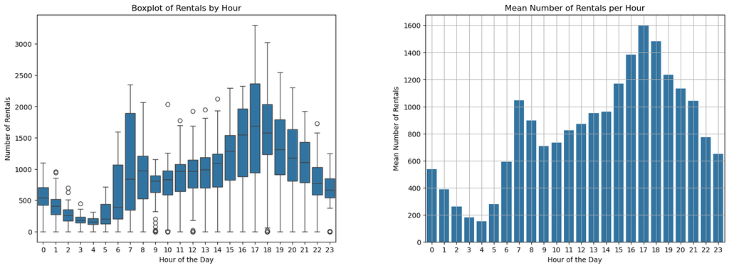

```python
# group the data by 'hour' and calculate the mean for 'RENTALS'
mean_rentals_per_hour = df_train.groupby('hour')['RENTALS'].mean().reset_index()

# creating subplots
plt.figure(figsize = (18, 6))

# plotting the boxplot
plt.subplot(1, 2, 1)
sns.boxplot(data = df_train,
               x = "hour",
               y = "RENTALS")

plt.title('Boxplot of Rentals by Hour')
plt.xlabel('Hour of the Day')
plt.ylabel('Number of Rentals')

# plotting the barplot
plt.subplot(1, 2, 2)
sns.barplot(x       = 'hour',
            y       = 'RENTALS',
            data    = mean_rentals_per_hour)

# title and labels
plt.title('Mean Number of Rentals per Hour')
plt.xlabel('Hour of the Day')
plt.ylabel('Mean Number of Rentals')
plt.xticks(range(24))
plt.grid(True)

# adjusting layout
plt.subplots_adjust(wspace = 0.3)
plt.show()
```

The boxplot shows the distribution of rentals for each hour of the day, the boxes represent the interquartile range (IQR), which is the range where the central 50% of the data is found. The lines (whiskers) extend to the maximum and minimum values, points outside the whiskers are considered outliers. On the other hand, the barplot shows the average rentals for each hour of the day, this provides a clearer view of overall trends without the dispersion of individual data.

Remarks: (0-5 AM): rentals are low and relatively stable, there are some outliers, especially around midnight and early morning hours and the average number of rentals is relatively low, not exceeding 600. Early morning: (6-9 AM): The number of rentals significantly increased, the median and IQR were highest at 7 AM, with an average of over 1000 bikes rented. Mid Morning (10 AM- 12 PM): The number of rentals decreases after the morning peak. Afternoon (1-4 PM): Rentals gradually increase during the afternoon. Afternoon Peak Hour (5-7 PM): Another significant increase is observed during these hours, reaching a second peak around 5-6 PM, aligning with the end of the workday, and it reaches 1600 bike rentals. Evening (8-11 PM): Rents decrease again after the afternoon peak, but remain relatively high until 9 PM before gradually declining around midnight.

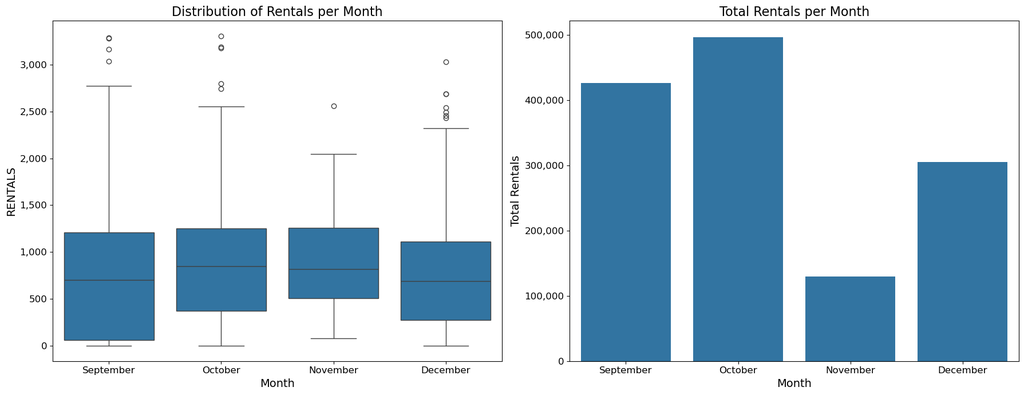

```python
# function to format digits with comma
def format_func(value, tick_number):
    return f'{int(value):,}'

# set figsize and create subplots
fig, axs = plt.subplots(1, 2,
                        figsize = (18, 7))

# create boxplot
sns.boxplot(x    ='month',
            y    = 'RENTALS',
            data = df_train,
            ax   = axs[0])

# title and labels
axs[0].set_title('Distribution of Rentals per Month',
                 fontsize  = 16)
axs[0].set_xlabel('Month',
                  fontsize = 14)
axs[0].set_ylabel('RENTALS',
                  fontsize = 14)
axs[0].set_xticks(range(4))
axs[0].set_xticklabels(['September', 'October', 'November', 'December'],
                       fontsize = 12)
axs[0].tick_params(axis = 'y',
                   labelsize = 12)

# formatting digits
axs[0].yaxis.set_major_formatter(FuncFormatter(format_func))

# group rentals by month
rentals_per_month = df_train.groupby('month')['RENTALS'].sum().reset_index()

# create barplot
sns.barplot(x    = 'month',
            y    = 'RENTALS',
            data = rentals_per_month,
            ax   = axs[1])

# title and lables
axs[1].set_title('Total Rentals per Month',
                 fontsize = 16)
axs[1].set_xlabel('Month',
                  fontsize = 14)
axs[1].set_ylabel('Total Rentals',
                  fontsize = 14)
axs[1].set_xticks(range(4))
axs[1].set_xticklabels(['September', 'October', 'November', 'December'],
                       fontsize = 12)
axs[1].tick_params(axis = 'y',
                   labelsize = 12)

# formatting digits
axs[1].yaxis.set_major_formatter(FuncFormatter(format_func))

# showing the plots
plt.tight_layout()
plt.show()
```

Regarding total rentals per month, we see that October has the highest number of rentals during the recorded period, with just under 500,000 bicycles rented in total, followed by September with approximately 420,000 bicycles rented, then December with an estimated 320,000, and finally November with around 140,000.

```python
# pearson correlation for RENTALS
rentals_corr = df_train.corr(method       = 'pearson',
                             numeric_only = True).round(decimals = 4)


# checking results
print(f"""
Correlations with Rentals
---------------------------
{rentals_corr.loc[ : , 'RENTALS' ].sort_values(ascending = False)}
""")
```

```
Correlations with Rentals
---------------------------
RENTALS                   1.0000
hour                      0.4229
Temperature(F)            0.3228
SolarRadiation(MJ/m2)     0.2047
Wind speed (mph)          0.1863
day_of_week               0.0967
quarter                   0.0449
DewPointTemperature(F)    0.0343
Visibility(miles)         0.0138
month                    -0.0124
Holiday_numeric          -0.0251
day                      -0.0761
Snowfall(in)             -0.0869
Rainfall(in)             -0.1458
Humidity(%)              -0.3953
Name: RENTALS, dtype: float64
```

### Creating new variables from Humidity and Temperature levels

```python
# create new variables based on Humidity and Temperature conditions on the train set
# define the conditions and choices based on temperature and humidity ranges
conditions = [
    # Cold
    (df_train['Temperature(F)'] <= 40) & (df_train['Humidity(%)'] <= 50),
    (df_train['Temperature(F)'] <= 40) & (df_train['Humidity(%)'] > 50),

    # Cool
    (df_train['Temperature(F)'] > 40) & (df_train['Temperature(F)'] <= 60) & (df_train['Humidity(%)'] <= 50),
    (df_train['Temperature(F)'] > 40) & (df_train['Temperature(F)'] <= 60) & (df_train['Humidity(%)'] > 50),

    # Mild
    (df_train['Temperature(F)'] > 60) & (df_train['Temperature(F)'] <= 75) & (df_train['Humidity(%)'] <= 50),
    (df_train['Temperature(F)'] > 60) & (df_train['Temperature(F)'] <= 75) & (df_train['Humidity(%)'] > 50),

    # Warm
    (df_train['Temperature(F)'] > 75) & (df_train['Humidity(%)'] <= 50),
    (df_train['Temperature(F)'] > 75) & (df_train['Humidity(%)'] > 50)
]

# define the corresponding choices for the conditions
choices = [
    'Cold and Dry/Moderate',
    'Cold and Humid',

    'Cool and Dry/Moderate',
    'Cool and Humid',

    'Mild and Dry/Moderate',
    'Mild and Humid',

    'Warm and Dry/Moderate',
    'Warm and Humid'
]

# create the 'Climate_Type' column in the dataframe
df_train['Climate_Type'] = np.select(conditions,
                                     choices,
                                     default = 'Unknown')

# checking results
df_train['Climate_Type'].value_counts()
```

```
Climate_Type
Cool and Humid           573
Mild and Humid           342
Cool and Dry/Moderate    213
Mild and Dry/Moderate    199
Cold and Humid            96
Warm and Dry/Moderate     95
Cold and Dry/Moderate     71
Warm and Humid            49
Name: count, dtype: int64
```

```python
# replicate the process on the test set
# define the conditions and choices based on temperature and humidity ranges
conditions = [
    # Cold
    (df_test['Temperature(F)'] <= 40) & (df_test['Humidity(%)'] <= 50),
    (df_test['Temperature(F)'] <= 40) & (df_test['Humidity(%)'] > 50),

    # Cool
    (df_test['Temperature(F)'] > 40) & (df_test['Temperature(F)'] <= 60) & (df_test['Humidity(%)'] <= 50),
    (df_test['Temperature(F)'] > 40) & (df_test['Temperature(F)'] <= 60) & (df_test['Humidity(%)'] > 50),

    # Mild
    (df_test['Temperature(F)'] > 60) & (df_test['Temperature(F)'] <= 75) & (df_test['Humidity(%)'] <= 50),
    (df_test['Temperature(F)'] > 60) & (df_test['Temperature(F)'] <= 75) & (df_test['Humidity(%)'] > 50),

    # Warm
    (df_test['Temperature(F)'] > 75) & (df_test['Humidity(%)'] <= 50),
    (df_test['Temperature(F)'] > 75) & (df_test['Humidity(%)'] > 50)
]

# define the corresponding choices for the conditions
choices = [
    'Cold and Dry/Moderate',
    'Cold and Humid',

    'Cool and Dry/Moderate',
    'Cool and Humid',

    'Mild and Dry/Moderate',
    'Mild and Humid',

    'Warm and Dry/Moderate',
    'Warm and Humid'
]

# create the 'Climate_Type' column in the dataframe
df_test['Climate_Type'] = np.select(conditions,
                                    choices,
                                    default = 'Unknown')

# checking results
df_test['Climate_Type'].value_counts()
```

```
Climate_Type
Cool and Humid           188
Mild and Humid           119
Cool and Dry/Moderate     69
Mild and Dry/Moderate     65
Cold and Humid            38
Warm and Dry/Moderate     33
Cold and Dry/Moderate     18
Warm and Humid            16
Name: count, dtype: int64
```

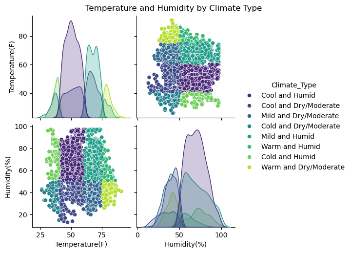

```python
# set up the seaborn pairplot
sns.pairplot(df_train,
             hue     = 'Climate_Type',
             vars    = ['Temperature(F)', 'Humidity(%)'],
             palette = 'viridis')

# add title
plt.suptitle('Temperature and Humidity by Climate Type',
             y = 1.02)

# show the plot
plt.show()
```

Bottom Left (Temperature vs. Humidity Scatter Plot Mirrored): This scatter plot mirrors the top right plot, providing the same information but with the axes swapped for a different comparison. It confirms the observed trends between temperature and humidity for different climate types. The clear separation between the climate types in this plot shows how each climate type has a distinct temperature and humidity profile.

Bottom Right (Humidity Distribution by Climate Type): This KDE plot shows the distribution of humidity for each climate type. The “Cool and Humid” climate has a distribution skewed towards higher humidity levels, indicating a generally more humid environment. The “Warm and Dry/Moderate” climate type, however, shows a peak at lower humidity levels, indicating drier conditions.

```python
# apply One-Hot Encoding to the 'Climate_Type' column on train set
df_train = pd.get_dummies(df_train,
                          columns    = ['Climate_Type'],
                          drop_first = True)

# apply One-Hot Encoding to the 'Climate_Type' column on test set
df_test  = pd.get_dummies(df_test,
                          columns = ['Climate_Type'],
                          drop_first = True)

# convert boolean columns to integers on train set
boolean_columns_train = df_train.select_dtypes(include = ['bool']).columns
df_train[boolean_columns_train] = df_train[boolean_columns_train].astype(int)

# convert boolean columns to integers on test set
boolean_columns_test = df_test.select_dtypes(include = ['bool']).columns
df_test[boolean_columns_test] = df_test[boolean_columns_test].astype(int)

# verify the changes
df_train.head()
```

| ID | DateHour | Temperature(F) | Humidity(%) | Wind speed (mph) | Visibility(miles) | DewPointTemperature(F) | Rainfall(in) | Snowfall(in) | SolarRadiation(MJ/m2) | RENTALS | set | Holiday_numeric | hour | day_of_week | month | day | quarter | Climate_Type_Cold and Humid | Climate_Type_Cool and Dry/Moderate | Climate_Type_Cool and Humid | Climate_Type_Mild and Dry/Moderate | Climate_Type_Mild and Humid | Climate_Type_Warm and Dry/Moderate | Climate_Type_Warm and Humid |
| --- | --- | --- | --- | --- | --- | --- | --- | --- | --- | --- | --- | --- | --- | --- | --- | --- | --- | --- | --- | --- | --- | --- | --- | --- |
| mb_1039 | 2023-10-14 05:59:54.810 | 52 | 81 | 0.4 | 2.90 | 46.4 | 0.0 | 0.0 | 0.00 | 519 | Not Kaggle | 0 | 5 | 5 | 10 | 14 | 4 | 0 | 0 | 1 | 0 | 0 | 0 | 0 |
| mb_1330 | 2023-10-26 08:59:53.355 | 51 | 53 | 2.2 | 7.22 | 35.2 | 0.0 | 0.0 | 1.01 | 1251 | Not Kaggle | 0 | 8 | 3 | 10 | 26 | 4 | 0 | 0 | 1 | 0 | 0 | 0 | 0 |
| mb_551 | 2023-09-23 21:59:57.250 | 56 | 49 | 2.5 | 3.40 | 38.8 | 0.0 | 0.0 | 0.00 | 1685 | Not Kaggle | 0 | 21 | 5 | 9 | 23 | 3 | 0 | 1 | 0 | 0 | 0 | 0 | 0 |
| mb_2103 | 2023-12-19 14:00:00.000 | 69 | 32 | 9.8 | 12.40 | 38.7 | 0.0 | 0.0 | 2.36 | 0 | Not Kaggle | 0 | 14 | 1 | 12 | 19 | 4 | 0 | 0 | 0 | 1 | 0 | 0 | 0 |
| mb_1430 | 2023-10-30 12:59:52.855 | 53 | 20 | 2.9 | 10.80 | 12.9 | 0.0 | 0.0 | 1.96 | 814 | Not Kaggle | 0 | 12 | 0 | 10 | 30 | 4 | 0 | 1 | 0 | 0 | 0 | 0 | 0 |

### Creating new features from time variables and correlated feature interactions

New features were created based on the interactions of variables with a strong correlation with Rentals.

solar_temp_ratio: This feature can describe sunny weather conditions with low temperature when is high and cloudly weather conditions whith high temperature when is low, which can be useful to predict rentals on different seasons.

wind_humidity_ratio: this feature can describe the classic weather conditions in Chicago "The windy City", with strong wind levels and variable humidity levels.

rush_hour: This is a powerful feature that sorts the most correlated variable with Rentals and indicates if the bike is rented during the peak hours, from 6 am to 8 am or from 16 pm to 18 pm.

is_weekend: this variable indicates if the rental was made on a weekend showing a number 1 or 0 for weekdays, this could be useful to have a clearer understanding of rentals trends over time.

```python
# feature engineering in the train set
df_train['solar_temp_ratio']          = df_train['SolarRadiation(MJ/m2)'] / (df_train['Temperature(F)'] + 1)
df_train['wind_humidity_ratio']       = df_train['Wind speed (mph)'] / (df_train['Humidity(%)'] + 1)
df_train['rush_hour']                 = ((df_train['hour'] >= 6) & (df_train['hour'] <= 8) | (df_train['hour'] >= 16) & (df_train['hour'] <= 18)).astype(int)
df_train['is_weekend']                = (df_train['day_of_week'].isin([5, 6])).astype(int)
df_train['norm_hour_temp_below_mean'] = np.where((df_train['rush_hour'] == 0) & (df_train['Temperature(F)'] < 57.39), 1, 0)
df_train['rush_hour_hum_below_mean']  = np.where((df_train['rush_hour'] == 1) & (df_train['Humidity(%)'] < 59.23), 1, 0)


# feature engineering in the test set
df_test['solar_temp_ratio']          = df_test['SolarRadiation(MJ/m2)'] / (df_test['Temperature(F)'] + 1)
df_test['wind_humidity_ratio']       = df_test['Wind speed (mph)'] / (df_test['Humidity(%)'] + 1)
df_test['rush_hour']                 = ((df_test['hour'] >= 6) & (df_test['hour'] <= 8) | (df_test['hour'] >= 16) & (df_test['hour'] <= 18)).astype(int)
df_test['is_weekend']                = (df_test['day_of_week'].isin([5, 6])).astype(int)
df_test['norm_hour_temp_below_mean'] = np.where((df_test['rush_hour'] == 0) & (df_test['Temperature(F)'] < 57.39), 1, 0)
df_test['rush_hour_hum_below_mean']  = np.where((df_test['rush_hour'] == 1) & (df_test['Humidity(%)'] < 59.23), 1, 0)

# checking results
df_train.head(n = 5)
```

| ID | DateHour | Temperature(F) | Humidity(%) | Wind speed (mph) | Visibility(miles) | DewPointTemperature(F) | Rainfall(in) | Snowfall(in) | SolarRadiation(MJ/m2) | RENTALS | set | Holiday_numeric | hour | day_of_week | month | day | quarter | Climate_Type_Cold and Humid | Climate_Type_Cool and Dry/Moderate | Climate_Type_Cool and Humid | Climate_Type_Mild and Dry/Moderate | Climate_Type_Mild and Humid | Climate_Type_Warm and Dry/Moderate | Climate_Type_Warm and Humid | solar_temp_ratio | wind_humidity_ratio | rush_hour | is_weekend | norm_hour_temp_below_mean | … |
| --- | --- | --- | --- | --- | --- | --- | --- | --- | --- | --- | --- | --- | --- | --- | --- | --- | --- | --- | --- | --- | --- | --- | --- | --- | --- | --- | --- | --- | --- | --- |
| mb_1039 | 2023-10-14 05:59:54.810 | 52 | 81 | 0.4 | 2.90 | 46.4 | 0.0 | 0.0 | 0.00 | 519 | Not Kaggle | 0 | 5 | 5 | 10 | 14 | 4 | 0 | 0 | 1 | 0 | 0 | 0 | 0 | 0.000000 | 0.004878 | 0 | 1 | 1 | … |
| mb_1330 | 2023-10-26 08:59:53.355 | 51 | 53 | 2.2 | 7.22 | 35.2 | 0.0 | 0.0 | 1.01 | 1251 | Not Kaggle | 0 | 8 | 3 | 10 | 26 | 4 | 0 | 0 | 1 | 0 | 0 | 0 | 0 | 0.019423 | 0.040741 | 1 | 0 | 0 | … |
| mb_551 | 2023-09-23 21:59:57.250 | 56 | 49 | 2.5 | 3.40 | 38.8 | 0.0 | 0.0 | 0.00 | 1685 | Not Kaggle | 0 | 21 | 5 | 9 | 23 | 3 | 0 | 1 | 0 | 0 | 0 | 0 | 0 | 0.000000 | 0.050000 | 0 | 1 | 1 | … |
| mb_2103 | 2023-12-19 14:00:00.000 | 69 | 32 | 9.8 | 12.40 | 38.7 | 0.0 | 0.0 | 2.36 | 0 | Not Kaggle | 0 | 14 | 1 | 12 | 19 | 4 | 0 | 0 | 0 | 1 | 0 | 0 | 0 | 0.033714 | 0.296970 | 0 | 0 | 0 | … |
| mb_1430 | 2023-10-30 12:59:52.855 | 53 | 20 | 2.9 | 10.80 | 12.9 | 0.0 | 0.0 | 1.96 | 814 | Not Kaggle | 0 | 12 | 0 | 10 | 30 | 4 | 0 | 1 | 0 | 0 | 0 | 0 | 0 | 0.036296 | 0.138095 | 0 | 0 | 1 | … |

```python
# pearson correlation for RENTALS
rentals_corr = df_train.corr(method       = 'pearson',
                             numeric_only = True).round(decimals = 4)


# checking results
print(f"""
Correlations with Rentals
---------------------------
{rentals_corr.loc[ : , 'RENTALS' ].sort_values(ascending = False)}
""")
```

```
Correlations with Rentals
---------------------------
RENTALS                               1.0000
hour                                  0.4229
rush_hour_hum_below_mean              0.3866
Temperature(F)                        0.3228
rush_hour                             0.3030
wind_humidity_ratio                   0.2684
Climate_Type_Mild and Dry/Moderate    0.2612
Climate_Type_Warm and Dry/Moderate    0.2385
SolarRadiation(MJ/m2)                 0.2047
Wind speed (mph)                      0.1863
solar_temp_ratio                      0.1690
Climate_Type_Warm and Humid           0.1542
Climate_Type_Cool and Dry/Moderate    0.1267
day_of_week                           0.0967
is_weekend                            0.0658
quarter                               0.0449
DewPointTemperature(F)                0.0343
Visibility(miles)                     0.0138
month                                -0.0124
Holiday_numeric                      -0.0251
day                                  -0.0761
Snowfall(in)                         -0.0869
Climate_Type_Cold and Humid          -0.0948
Climate_Type_Mild and Humid          -0.1064
Rainfall(in)                         -0.1458
Climate_Type_Cool and Humid          -0.2697
norm_hour_temp_below_mean            -0.3169
Humidity(%)                          -0.3953
Name: RENTALS, dtype: float64
```

## Preparing data for modeling

```python
# creating a new DataFrame to prepare data for modeling
df_full = pd.concat(objs     = [df_train, df_test],
                            axis         = 0,
                            ignore_index = False)

# checking results
df_full.head(n = 5)
```

| ID | DateHour | Temperature(F) | Humidity(%) | Wind speed (mph) | Visibility(miles) | DewPointTemperature(F) | Rainfall(in) | Snowfall(in) | SolarRadiation(MJ/m2) | RENTALS | set | Holiday_numeric | hour | day_of_week | month | day | quarter | Climate_Type_Cold and Humid | Climate_Type_Cool and Dry/Moderate | Climate_Type_Cool and Humid | Climate_Type_Mild and Dry/Moderate | Climate_Type_Mild and Humid | Climate_Type_Warm and Dry/Moderate | Climate_Type_Warm and Humid | solar_temp_ratio | wind_humidity_ratio | rush_hour | is_weekend | norm_hour_temp_below_mean | … |
| --- | --- | --- | --- | --- | --- | --- | --- | --- | --- | --- | --- | --- | --- | --- | --- | --- | --- | --- | --- | --- | --- | --- | --- | --- | --- | --- | --- | --- | --- | --- |
| mb_1039 | 2023-10-14 05:59:54.810 | 52 | 81 | 0.4 | 2.90 | 46.4 | 0.0 | 0.0 | 0.00 | 519.0 | Not Kaggle | 0 | 5 | 5 | 10 | 14 | 4 | 0 | 0 | 1 | 0 | 0 | 0 | 0 | 0.000000 | 0.004878 | 0 | 1 | 1 | … |
| mb_1330 | 2023-10-26 08:59:53.355 | 51 | 53 | 2.2 | 7.22 | 35.2 | 0.0 | 0.0 | 1.01 | 1251.0 | Not Kaggle | 0 | 8 | 3 | 10 | 26 | 4 | 0 | 0 | 1 | 0 | 0 | 0 | 0 | 0.019423 | 0.040741 | 1 | 0 | 0 | … |
| mb_551 | 2023-09-23 21:59:57.250 | 56 | 49 | 2.5 | 3.40 | 38.8 | 0.0 | 0.0 | 0.00 | 1685.0 | Not Kaggle | 0 | 21 | 5 | 9 | 23 | 3 | 0 | 1 | 0 | 0 | 0 | 0 | 0 | 0.000000 | 0.050000 | 0 | 1 | 1 | … |
| mb_2103 | 2023-12-19 14:00:00.000 | 69 | 32 | 9.8 | 12.40 | 38.7 | 0.0 | 0.0 | 2.36 | 0.0 | Not Kaggle | 0 | 14 | 1 | 12 | 19 | 4 | 0 | 0 | 0 | 1 | 0 | 0 | 0 | 0.033714 | 0.296970 | 0 | 0 | 0 | … |
| mb_1430 | 2023-10-30 12:59:52.855 | 53 | 20 | 2.9 | 10.80 | 12.9 | 0.0 | 0.0 | 1.96 | 814.0 | Not Kaggle | 0 | 12 | 0 | 10 | 30 | 4 | 0 | 1 | 0 | 0 | 0 | 0 | 0 | 0.036296 | 0.138095 | 0 | 0 | 1 | … |

### Separating the Kaggle Data

```python
## parsing out testing data (needed for later) ##

# dataset for kaggle
kaggle_data = df_full[ df_full['set'] == 'Kaggle' ].copy()


# dataset for model building
df = df_full[ df_full['set'] == 'Not Kaggle' ].copy()


# dropping set identifier (kaggle)
kaggle_data.drop(labels = 'set',
                 axis = 1,
                 inplace = True)


# dropping set identifier (model building)
df.drop(labels = 'set',
        axis = 1,
        inplace = True)
```

### Candidate modeling

Based on correlations, level of significance and VIF analysis.

```python
# pearson correlation for RENTALS
rentals_corr = df_train.corr(method       = 'pearson',
                             numeric_only = True).round(decimals = 4)


# checking results
print(f"""
Correlations with Rentals
---------------------------
{rentals_corr.loc[ : , 'RENTALS' ].sort_values(ascending = False)}
""")
```

```
Correlations with Rentals
---------------------------
RENTALS                               1.0000
hour                                  0.4229
rush_hour_hum_below_mean              0.3866
Temperature(F)                        0.3228
rush_hour                             0.3030
wind_humidity_ratio                   0.2684
Climate_Type_Mild and Dry/Moderate    0.2612
Climate_Type_Warm and Dry/Moderate    0.2385
SolarRadiation(MJ/m2)                 0.2047
Wind speed (mph)                      0.1863
solar_temp_ratio                      0.1690
Climate_Type_Warm and Humid           0.1542
Climate_Type_Cool and Dry/Moderate    0.1267
day_of_week                           0.0967
is_weekend                            0.0658
quarter                               0.0449
DewPointTemperature(F)                0.0343
Visibility(miles)                     0.0138
month                                -0.0124
Holiday_numeric                      -0.0251
day                                  -0.0761
Snowfall(in)                         -0.0869
Climate_Type_Cold and Humid          -0.0948
Climate_Type_Mild and Humid          -0.1064
Rainfall(in)                         -0.1458
Climate_Type_Cool and Humid          -0.2697
norm_hour_temp_below_mean            -0.3169
Humidity(%)                          -0.3953
Name: RENTALS, dtype: float64
```

```python
# drop the target variable
x = df_train.drop(columns=['RENTALS',
                          'DateHour', 'set'])

# add a constant to calculate the VIF
x_const = add_constant(X)

# calculate the VIF for each variable
vif_data = pd.DataFrame()
vif_data['Variable'] = x_const.columns
vif_data['VIF'] = [variance_inflation_factor(x_const.values, i) for i in range(x_const.shape[1])]

vif_data.round(2)
```

|  | Variable | VIF |
| --- | --- | --- |
| 0 | const | 400.30 |
| 1 | Temperature(F) | 19.99 |
| 2 | Humidity(%) | 8.74 |
| 3 | Wind speed (mph) | 6.66 |
| 4 | Visibility(miles) | 1.17 |
| 5 | DewPointTemperature(F) | 14.95 |
| 6 | Rainfall(in) | 1.18 |
| 7 | Snowfall(in) | 1.24 |
| 8 | SolarRadiation(MJ/m2) | 42.70 |
| 9 | Holiday_numeric | 1.14 |
| 10 | hour | 1.31 |
| 11 | day_of_week | 2.65 |
| 12 | month | 2.78 |
| 13 | day | 1.13 |
| 14 | quarter | 2.60 |
| 15 | Climate_Type_Cold and Humid | 3.11 |
| 16 | Climate_Type_Cool and Dry/Moderate | 5.05 |
| 17 | Climate_Type_Cool and Humid | 10.64 |
| 18 | Climate_Type_Mild and Dry/Moderate | 8.68 |
| 19 | Climate_Type_Mild and Humid | 14.26 |
| 20 | Climate_Type_Warm and Dry/Moderate | 7.77 |
| 21 | Climate_Type_Warm and Humid | 4.36 |
| 22 | solar_temp_ratio | 36.47 |
| 23 | wind_humidity_ratio | 10.44 |
| 24 | rush_hour | 2.96 |
| 25 | is_weekend | 2.67 |
| 26 | norm_hour_temp_below_mean | 3.42 |
| 27 | rush_hour_hum_below_mean | 2.36 |

```python
# defining x data and y data
x = df_train.drop(columns=['RENTALS', 'DateHour', 'set'])
y = df_train['RENTALS']

# splitting the data into training and testing sets
x_train, x_test, y_train, y_test = train_test_split(x, y, test_size=0.2, random_state=42)

# training the Random Forest Regressor
rf = RandomForestRegressor(n_estimators=100, random_state=42)
rf.fit(x_train, y_train)

# getting feature importances
importances = rf.feature_importances_

# creating a DataFrame
feature_importances = pd.DataFrame({'Feature': X.columns, 'Importance': importances})
feature_importances = feature_importances.sort_values(by='Importance', ascending=False)

# checking results
feature_importances
```

|  | Feature | Importance |
| --- | --- | --- |
| 9 | hour | 0.310724 |
| 0 | Temperature(F) | 0.102439 |
| 26 | rush_hour_hum_below_mean | 0.096176 |
| 1 | Humidity(%) | 0.090196 |
| 4 | DewPointTemperature(F) | 0.056959 |
| 3 | Visibility(miles) | 0.047693 |
| 12 | day | 0.046363 |
| 22 | wind_humidity_ratio | 0.046248 |
| 21 | solar_temp_ratio | 0.036211 |
| 10 | day_of_week | 0.035522 |
| 7 | SolarRadiation(MJ/m2) | 0.028623 |
| 2 | Wind speed (mph) | 0.026208 |
| 11 | month | 0.018060 |
| 23 | rush_hour | 0.011221 |
| 13 | quarter | 0.008937 |
| 8 | Holiday_numeric | 0.006811 |
| 18 | Climate_Type_Mild and Humid | 0.006639 |
| 25 | norm_hour_temp_below_mean | 0.006479 |
| 5 | Rainfall(in) | 0.005492 |
| 17 | Climate_Type_Mild and Dry/Moderate | 0.004265 |
| 16 | Climate_Type_Cool and Humid | 0.002261 |
| 24 | is_weekend | 0.001981 |
| 15 | Climate_Type_Cool and Dry/Moderate | 0.001083 |
| 19 | Climate_Type_Warm and Dry/Moderate | 0.000999 |
| 14 | Climate_Type_Cold and Humid | 0.000978 |
| 20 | Climate_Type_Warm and Humid | 0.000804 |
| 6 | Snowfall(in) | 0.000628 |

```python
#################
## full models ##
#################

# all x-data
x_all = list(df_full.columns)
x_all.remove('RENTALS')
x_all.remove('DateHour')


################
## original y ##
################

# base model, original X variables
x_base = ['hour',  'Temperature(F)', 'SolarRadiation(MJ/m2)',
          'Wind speed (mph)', 'Rainfall(in)', 'Humidity(%)', 'Snowfall(in)',
          'Visibility(miles)', 'DewPointTemperature(F)']



# best model after feature analysis
x_rich = ['Humidity(%)', 'Temperature(F)', 'Wind speed (mph)', 'Visibility(miles)', 'quarter'
          'Rainfall(in)', 'Snowfall(in)','SolarRadiation(MJ/m2)', 'Holiday_numeric','day_of_week',
          'hour', 'wind_humidity_ratio', 'solar_temp_ratio', 'rush_hour', 'rush_hour_hum_below_mean',
          'Climate_Type_Cool and Humid', 'norm_hour_temp_below_mean']


# best model after backward selection
x_best =  ['hour', 'rush_hour_hum_below_mean', 'rush_hour', 'wind_humidity_ratio',
           'Wind speed (mph)', 'day_of_week', 'quarter', 'Visibility(miles)', 'Humidity(%)',
           'Climate_Type_Cool and Humid', 'norm_hour_temp_below_mean', 'solar_temp_ratio', 'rush_hour_hum_below_mean']



########################
## response variable  ##
########################
original_y = df_train.loc[ : , 'RENTALS']
```

### Defining the variables with the best features

```python
x_features = ["hour", "rush_hour_hum_below_mean", 'Temperature(F)',
              "rush_hour", "wind_humidity_ratio",
              "Wind speed (mph)", "day_of_week", "quarter", "Visibility(miles)",
              'Humidity(%)', 'Climate_Type_Cool and Humid', 'rush_hour_hum_below_mean']


y_variable = 'RENTALS'
```

### Standardization

```python
# preparing explanatory variable data for standardization
rentals_data   = df.drop(['RENTALS',
                          #'yeojohnson_RENTALS',
                          #'log_RENTALS',
                          'DateHour'],
                                          #'ID'],
                                       axis = 1)


# preparing the target variable
rentals_target = df.loc[ : , 'RENTALS']
```

```python
# INSTANTIATING a StandardScaler() object
scaler = StandardScaler()


# FITTING the scaler with the data
scaler.fit(rentals_data)


# TRANSFORMING our data after fit
x_scaled = scaler.transform(rentals_data)


# converting scaled data into a DataFrame
x_scaled_df = pd.DataFrame(x_scaled)


# checking the results
x_scaled_df.describe(include = 'number').round(decimals = 2)
```

|  | 0 | 1 | 2 | 3 | 4 | 5 | 6 | 7 | 8 | 9 | 10 | 11 | 12 | 13 | 14 | 15 | 16 | 17 | 18 | 19 | 20 | 21 | 22 | 23 | 24 | 25 | 26 |
| --- | --- | --- | --- | --- | --- | --- | --- | --- | --- | --- | --- | --- | --- | --- | --- | --- | --- | --- | --- | --- | --- | --- | --- | --- | --- | --- | --- |
| count | 1638.00 | 1638.00 | 1638.00 | 1638.00 | 1638.00 | 1638.00 | 1638.00 | 1638.00 | 1638.00 | 1638.00 | 1638.00 | 1638.00 | 1638.00 | 1638.00 | 1638.00 | 1638.00 | 1638.00 | 1638.00 | 1638.00 | 1638.00 | 1638.00 | 1638.00 | 1638.00 | 1638.00 | 1638.00 | 1638.00 | 1638.00 |
| mean | 0.00 | 0.00 | -0.00 | -0.00 | -0.00 | -0.00 | 0.00 | -0.00 | -0.00 | 0.00 | 0.00 | 0.00 | 0.00 | 0.00 | 0.00 | 0.00 | 0.00 | -0.00 | -0.00 | -0.00 | 0.00 | -0.00 | -0.00 | 0.00 | 0.00 | 0.00 | -0.00 |
| std | 1.00 | 1.00 | 1.00 | 1.00 | 1.00 | 1.00 | 1.00 | 1.00 | 1.00 | 1.00 | 1.00 | 1.00 | 1.00 | 1.00 | 1.00 | 1.00 | 1.00 | 1.00 | 1.00 | 1.00 | 1.00 | 1.00 | 1.00 | 1.00 | 1.00 | 1.00 | 1.00 |
| min | -2.43 | -2.48 | -1.62 | -2.76 | -3.14 | -0.13 | -0.10 | -0.68 | -0.24 | -1.66 | -1.53 | -1.08 | -1.68 | -1.42 | -0.25 | -0.39 | -0.73 | -0.37 | -0.51 | -0.25 | -0.18 | -0.70 | -1.20 | -0.58 | -0.63 | -0.78 | -0.37 |
| 25% | -0.80 | -0.81 | -0.75 | -0.65 | -0.60 | -0.13 | -0.10 | -0.68 | -0.24 | -0.94 | -1.03 | -1.08 | -0.88 | -1.42 | -0.25 | -0.39 | -0.73 | -0.37 | -0.51 | -0.25 | -0.18 | -0.70 | -0.71 | -0.58 | -0.63 | -0.78 | -0.37 |
| 50% | -0.03 | -0.00 | -0.22 | 0.53 | -0.00 | -0.13 | -0.10 | -0.67 | -0.24 | 0.06 | -0.02 | -0.21 | 0.03 | 0.70 | -0.25 | -0.39 | -0.73 | -0.37 | -0.51 | -0.25 | -0.18 | -0.69 | -0.27 | -0.58 | -0.63 | -0.78 | -0.37 |
| 75% | 0.81 | 0.75 | 0.55 | 0.82 | 0.67 | -0.13 | -0.10 | 0.49 | -0.24 | 0.92 | 0.99 | 0.66 | 0.83 | 0.70 | -0.25 | -0.39 | 1.36 | -0.37 | -0.51 | -0.25 | -0.18 | 0.58 | 0.42 | 1.73 | 1.58 | 1.27 | -0.37 |
| max | 2.61 | 2.05 | 4.54 | 0.82 | 2.14 | 19.38 | 16.66 | 3.35 | 4.25 | 1.64 | 1.49 | 1.53 | 1.74 | 0.70 | 4.01 | 2.59 | 1.36 | 2.69 | 1.95 | 4.03 | 5.69 | 3.06 | 5.63 | 1.73 | 1.58 | 1.27 | 2.67 |

```python
# adding labels to the scaled DataFrame
x_scaled_df.columns = rentals_data.columns

#  Checking pre- and post-scaling of the data
print(f"""
Dataset BEFORE Scaling
----------------------
{np.var(rentals_data)}


Dataset AFTER Scaling
----------------------
{np.var(x_scaled_df)}
""")
```

```
Dataset BEFORE Scaling
----------------------
Temperature(F)                        166.922190
Humidity(%)                           344.375784
Wind speed (mph)                        4.329730
Visibility(miles)                      11.989046
DewPointTemperature(F)                195.555219
Rainfall(in)                            0.001325
Snowfall(in)                            0.000320
SolarRadiation(MJ/m2)                   0.622796
Holiday_numeric                         0.049746
hour                                   48.496274
day_of_week                             3.946628
month                                   1.328610
day                                    77.127855
quarter                                 0.221402
Climate_Type_Cold and Humid             0.055173
Climate_Type_Cool and Dry/Moderate      0.113127
Climate_Type_Cool and Humid             0.227445
Climate_Type_Mild and Dry/Moderate      0.106730
Climate_Type_Mild and Humid             0.165197
Climate_Type_Warm and Dry/Moderate      0.054634
Climate_Type_Warm and Humid             0.029020
solar_temp_ratio                        0.000144
wind_humidity_ratio                     0.003136
rush_hour                               0.187957
is_weekend                              0.204343
norm_hour_temp_below_mean               0.235828
rush_hour_hum_below_mean                0.107653
dtype: float64


Dataset AFTER Scaling
----------------------
Temperature(F)                        1.0
Humidity(%)                           1.0
Wind speed (mph)                      1.0
Visibility(miles)                     1.0
DewPointTemperature(F)                1.0
Rainfall(in)                          1.0
Snowfall(in)                          1.0
SolarRadiation(MJ/m2)                 1.0
Holiday_numeric                       1.0
hour                                  1.0
day_of_week                           1.0
month                                 1.0
day                                   1.0
quarter                               1.0
Climate_Type_Cold and Humid           1.0
Climate_Type_Cool and Dry/Moderate    1.0
Climate_Type_Cool and Humid           1.0
Climate_Type_Mild and Dry/Moderate    1.0
Climate_Type_Mild and Humid           1.0
Climate_Type_Warm and Dry/Moderate    1.0
Climate_Type_Warm and Humid           1.0
solar_temp_ratio                      1.0
wind_humidity_ratio                   1.0
rush_hour                             1.0
is_weekend                            1.0
norm_hour_temp_below_mean             1.0
rush_hour_hum_below_mean              1.0
dtype: float64
```

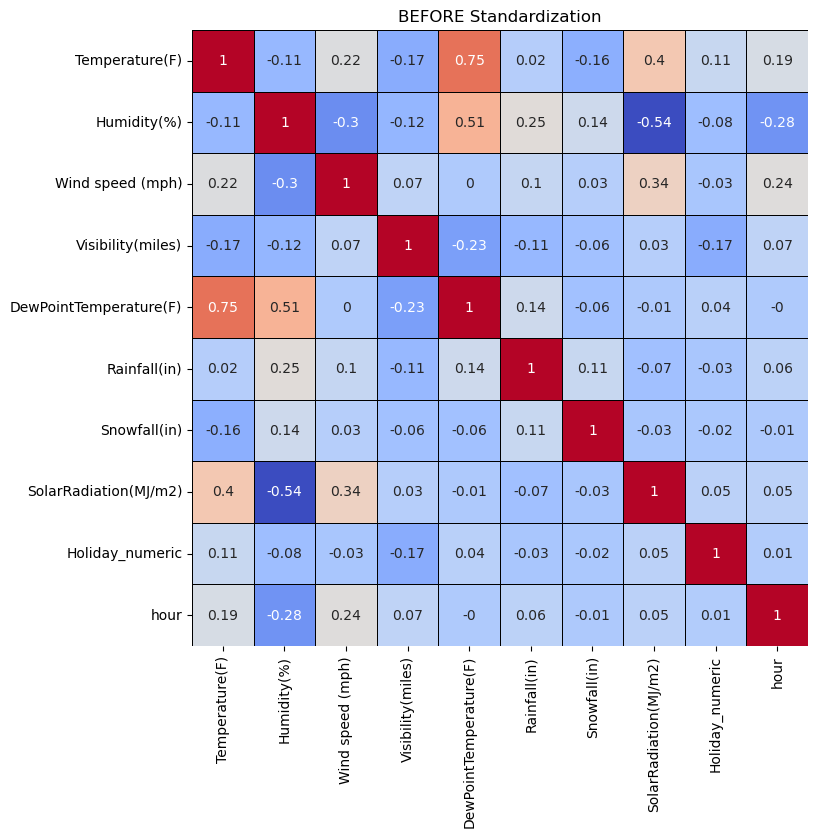

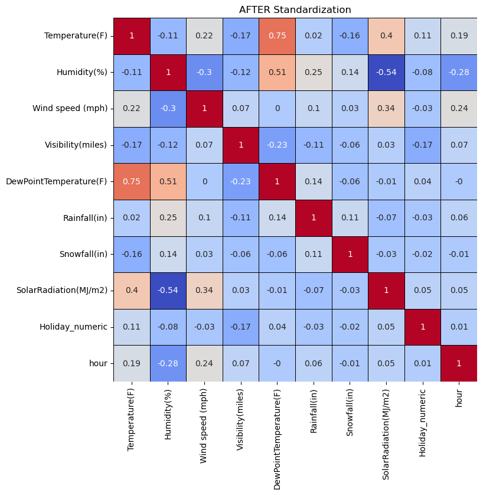

```python
######################
## Unscaled Dataset ##
######################

# subsetting the original dataset
rentals_subset = rentals_data.loc[:, ['Temperature(F)', 'Humidity(%)',
                                      'Wind speed (mph)', 'Visibility(miles)',
                                      'DewPointTemperature(F)', 'Rainfall(in)',
                                      'Snowfall(in)', 'SolarRadiation(MJ/m2)',
                                      'Holiday_numeric', 'hour']]

# UNSCALED correlation matrix
df_corr = rentals_subset.corr().round(2)

# heatmap of UNSCALED correlations
plt.figure(figsize = (10, 8))
sns.heatmap(df_corr,
            cmap       = 'coolwarm',
            square     = True,
            annot      = True,
            cbar       = False,
            linecolor  = 'black',
            linewidths = 0.5)

# checking results
plt.title("BEFORE Standardization")
plt.show()

####################
## Scaled Dataset ##
####################

# SCALED correlation matrix
df_scaled_corr = x_scaled_df.loc[:, ['Temperature(F)', 'Humidity(%)',
                                     'Wind speed (mph)', 'Visibility(miles)',
                                     'DewPointTemperature(F)', 'Rainfall(in)',
                                     'Snowfall(in)', 'SolarRadiation(MJ/m2)',
                                     'Holiday_numeric', 'hour']].corr().round(2)

# heatmap of SCALED correlations
plt.figure(figsize = (10, 8))
sns.heatmap(df_scaled_corr,
            cmap       = 'coolwarm',
            square     = True,
            annot      = True,
            cbar       = False,
            linecolor  = 'black',
            linewidths = 0.5)

# checking results
plt.title("AFTER Standardization")
plt.show()
```

Correlations remained the same after scaling the dataset

### Splitting the scaled dataset

```python
# preparing x-data
# removing non-numeric columns and missing values
x_data = x_scaled_df[x_features].copy().select_dtypes(include=['int64', 'float64']).dropna(axis=1)


# preparing y-data
y_data = df[y_variable]

# store training columns
train_columns = x_data.columns.tolist()


# train-test split
x_train_STAND, x_test_STAND, y_train_STAND, y_test_STAND = train_test_split(
            x_data,
            y_data,
            test_size = 0.25,
            random_state = 702)
```

### Modeling with RandomForestRegressor

```python
# define the parameter grid
param_grid = {
    'n_estimators': [100, 120],
    'max_features': [1.0],
    'max_depth': [3, 5],
    'min_samples_split': [9, 15],
    'min_samples_leaf': [5, 10],
    'bootstrap': [True]

}

# initialize Random Forest Regressor
rf = RandomForestRegressor(random_state = 42)

# define the Cross-Validation strategy
cv_strategy = KFold(n_splits     = 6,
                    shuffle      = True,
                    random_state = 42)

# initialize GridSearchCV
grid_search = GridSearchCV(estimator  = rf,
                           param_grid = param_grid,
                           cv         = cv_strategy,
                           n_jobs     = -1,
                           verbose    = 2,
                           scoring    = 'neg_mean_squared_error')

# adjust GridSearchCV to the data
grid_search.fit(x_train_STAND, y_train_STAND)

# extract the best parameters
best_params = grid_search.best_params_
print("Best parameters found: ", best_params)

# train the model with the best parametres
best_rf = grid_search.best_estimator_

# precit on the test set
RF_pred = best_rf.predict(x_test_STAND)

# calculate MSE
RF_mse = mean_squared_error(y_test_STAND, RF_pred).round(decimals = 4)
print("Mean Squared Error: ", RF_mse)

# saving scoring data for future use
RF_train_score = best_rf.score(x_train_STAND, y_train_STAND).round(decimals = 4)
RF_test_score  = best_rf.score(x_test_STAND, y_test_STAND)  .round(decimals = 4)

# print the scores of train and test
print("Random Forest Training Score: ", RF_train_score)
print("Random Forest Testing Score: ", RF_test_score)

# saving and printing the gap between training and testing
RF_train_test_gap = abs(RF_train_score - RF_test_score).round(decimals = 4)
print('Random Forest Train-Test Gap:', RF_train_test_gap)
```

```
Fitting 6 folds for each of 16 candidates, totalling 96 fits
Best parameters found:  {'bootstrap': True, 'max_depth': 5, 'max_features': 1.0, 'min_samples_leaf': 5, 'min_samples_split': 9, 'n_estimators': 100}
Mean Squared Error:  227870.9135
Random Forest Training Score:  0.5623
Random Forest Testing Score:  0.5032
Random Forest Train-Test Gap: 0.0591
```

### GradientBoostingRegressor

```python
# naming the model
model = GradientBoostingRegressor()
model.fit(x_train_STAND, y_train_STAND)
y_pred = model.predict(x_test_STAND)

# evaluate model performance
GBR_mse = mean_squared_error(y_test_STAND, y_pred).round(decimals = 4)
print("Mean Squared Error:", GBR_mse)

# scoring the results
print('GradientBoostingRegressor Training Score:', model.score(x_train_STAND, y_train_STAND).round(decimals = 4))
print('GradientBoostingRegressor Testing Score :',  model.score(x_test_STAND, y_test_STAND) .round(decimals = 4))

# storing scoring data for future use
GBR_stand_score_train = model.score(x_train_STAND, y_train_STAND).round(decimals = 4)
GBR_stand_score_test  = model.score(x_test_STAND, y_test_STAND)  .round(decimals = 4)


# displaying and saving the gap between training and testing
GBR_train_test_gap = abs(GBR_stand_score_train - GBR_stand_score_test).round(decimals = 4)
print('GradientBoostingRegressor Train-Test Gap:', GBR_train_test_gap)
```

```
Mean Squared Error: 201889.1745
GradientBoostingRegressor Training Score: 0.6866
GradientBoostingRegressor Testing Score : 0.5598
GradientBoostingRegressor Train-Test Gap: 0.1268
```

```python
# define the param grid
param_grid = {
    'n_estimators': [100, 150],
    'learning_rate': [0.01, 0.03],
    'max_depth': [1, 3],
    'subsample': [0.8, 1.0],
    'max_features': ['sqrt', 'log2'],
    'min_samples_split': [5, 10],
    'min_samples_leaf': [4, 6]
}

# initialize the model
GBR_model = GradientBoostingRegressor(random_state = 42)

# set the GridSearch
grid_search = GridSearchCV(estimator  = GBR_model,
                           param_grid = param_grid,
                           cv         = 5,
                           scoring    = 'neg_mean_squared_error',
                           n_jobs     = -1,
                           verbose    = 2)

# fit the GridSearch on the training set
grid_search.fit(x_train_STAND, y_train_STAND)

# extract the best parameters
best_params = grid_search.best_params_
print("Best parameters found: ", best_params)

# train the model with the best parameters
best_model = grid_search.best_estimator_
best_model.fit(x_train_STAND, y_train_STAND)

# predict on the train set
GBR_pred = best_model.predict(x_test_STAND)

# store the scores
GBR_train_score = best_model.score(x_train_STAND, y_train_STAND).round(decimals = 4)
GBR_test_score  = best_model.score(x_test_STAND, y_test_STAND) .round(decimals = 4)
GBR_train_test_gap = abs(best_model.score(x_train_STAND, y_train_STAND) - best_model.score(x_test_STAND, y_test_STAND)).round(decimals = 4)

# evaluate the model
GBR_mse = mean_squared_error(y_test_STAND, GBR_pred).round(decimals = 4)
print("Mean Squared Error:", GBR_mse)
print('GradientBoostingRegressor Training Score:', GBR_train_score)
print('GradientBoostingRegressor Testing Score :', GBR_test_score)
print('GradientBoostingRegressor Train-Test Gap:', GBR_train_test_gap)
```

```
Fitting 5 folds for each of 128 candidates, totalling 640 fits
Best parameters found:  {'learning_rate': 0.03, 'max_depth': 3, 'max_features': 'sqrt', 'min_samples_leaf': 6, 'min_samples_split': 5, 'n_estimators': 150, 'subsample': 1.0}
Mean Squared Error: 212996.6029
GradientBoostingRegressor Training Score: 0.5847
GradientBoostingRegressor Testing Score : 0.5356
GradientBoostingRegressor Train-Test Gap: 0.0491
```

### Modeling with KNeighborsRegressor

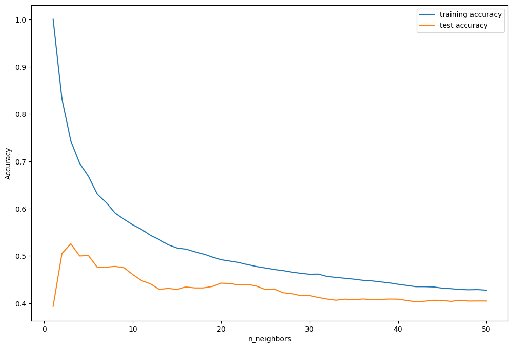

```
The optimal number of neighbors is 3
```

```python
# creating lists for training set accuracy and test set accuracy
training_accuracy = []
test_accuracy = []


# building a visualization of 1 to 50 neighbors
neighbors_settings = range(1, 51)


for n_neighbors in neighbors_settings:
    # building the model
    clf = KNeighborsRegressor(n_neighbors = n_neighbors)
    clf.fit(x_train_STAND, y_train_STAND)

    # recording the training set accuracy
    training_accuracy.append(clf.score(x_train_STAND, y_train_STAND))

    # recording the generalization accuracy
    test_accuracy.append(clf.score(x_test_STAND, y_test_STAND))


# plotting the visualization
fig, ax = plt.subplots(figsize = (12,8))
plt.plot(neighbors_settings, training_accuracy, label = "training accuracy")
plt.plot(neighbors_settings, test_accuracy,     label = "test accuracy")
plt.ylabel("Accuracy")
plt.xlabel("n_neighbors")
plt.legend()
plt.show()


# finding the optimal number of neighbors
opt_neighbors = test_accuracy.index(max(test_accuracy)) + 1
print(f"""The optimal number of neighbors is {opt_neighbors}""")
```

```python
# instantiating a model with the optimal number of neighbors
knn_stand = KNeighborsRegressor(algorithm = 'auto',
                                n_neighbors = opt_neighbors)



# fitting the model based on the training data
knn_stand_fit = knn_stand.fit(x_train_STAND, y_train_STAND)



# predicting on new data
knn_stand_pred = knn_stand_fit.predict(x_test_STAND)

# calculate MSE
KNN_mse = mean_squared_error(y_test_STAND, y_pred).round(decimals = 4)
print("Mean Squared Error:", KNN_mse)


# scoring the results
print('KNN Training Score:', knn_stand.score(x_train_STAND, y_train_STAND).round(4))
print('KNN Testing Score :',  knn_stand.score(x_test_STAND, y_test_STAND).round(4))


# saving scoring data for future use
KNN_train_score = knn_stand.score(x_train_STAND, y_train_STAND).round(4)
KNN_test_score  = knn_stand.score(x_test_STAND, y_test_STAND).round(4)


# displaying and saving the gap between training and testing
print('KNN Train-Test Gap:', abs(KNN_train_score - KNN_test_score).round(4))
KNN_train_test_gap = abs(KNN_train_score - KNN_test_score).round(4)
```

```
Mean Squared Error: 201889.1745
KNN Training Score: 0.743
KNN Testing Score : 0.5257
KNN Train-Test Gap: 0.2173
```

```python
# comparing results
print(f"""
Model                                        Train Score      Test Score       Train-Test Gap      MSE Error
----------------                            ------------    ------------    --------------        ------------------
RandomForestRegressor-Standardized           {RF_train_score:<15}    {RF_test_score:<15}    {RF_train_test_gap:<15}   {RF_mse:<15}
GradientBoostingRegressor-Standardized       {GBR_train_score:<15}    {GBR_test_score:<15}    {GBR_train_test_gap:<15}   {GBR_mse:<15}
KNeighborsRegressor-Standardized             {KNN_train_score:<15}    {KNN_test_score:<15}    {KNN_train_test_gap:<15}   {KNN_mse:<15}
""")
```

```
Model                                        Train Score      Test Score       Train-Test Gap      MSE Error
----------------                            ------------    ------------    --------------        ------------------
RandomForestRegressor-Standardized           0.5623             0.5032             0.0591            227870.9135
GradientBoostingRegressor-Standardized       0.5847             0.5356             0.0491            212996.6029
KNeighborsRegressor-Standardized             0.743              0.5257             0.2173            201889.1745
```

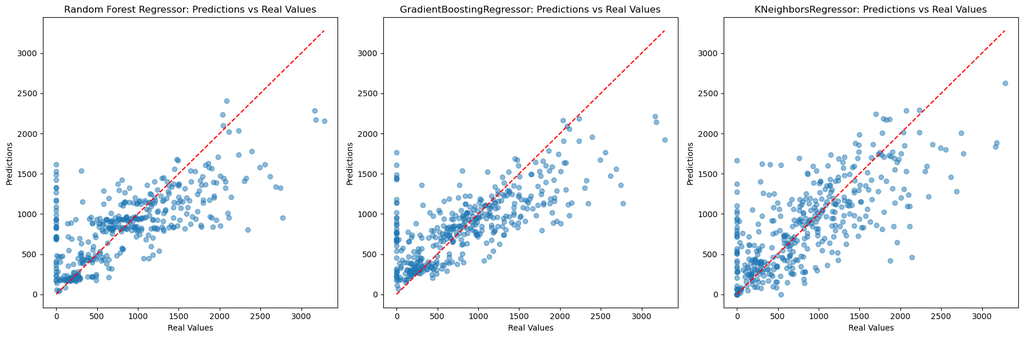

```python
# set the subplots
fig, axs = plt.subplots(1, 3, figsize = (18, 6))

# create a scatterplot for RandomForestRegressor
axs[0].scatter(y_test_STAND,
               RF_pred,
               alpha = 0.5)

# labels and title
axs[0].set_xlabel('Real Values')
axs[0].set_ylabel('Predictions')
axs[0].set_title('Random Forest Regressor: Predictions vs Real Values')
axs[0].plot([y_test_STAND.min(), y_test_STAND.max()],
            [y_test_STAND.min(), y_test_STAND.max()],
            color = 'red', linestyle = '--')

# create a scatterplot for GradientBoostingRegressor
axs[1].scatter(y_test_STAND,
               GBR_pred,
               alpha = 0.5)

# labels and title
axs[1].set_xlabel('Real Values')
axs[1].set_ylabel('Predictions')
axs[1].set_title('GradientBoostingRegressor: Predictions vs Real Values')
axs[1].plot([y_test_STAND.min(), y_test_STAND.max()],
            [y_test_STAND.min(), y_test_STAND.max()],
            color = 'red', linestyle = '--')

# create a scatterplot for KNeighborsRegressor
axs[2].scatter(y_test_STAND,
               knn_stand_pred,
               alpha = 0.5)

# labels and title
axs[2].set_xlabel('Real Values')
axs[2].set_ylabel('Predictions')
axs[2].set_title('KNeighborsRegressor: Predictions vs Real Values')
axs[2].plot([y_test_STAND.min(), y_test_STAND.max()],
            [y_test_STAND.min(), y_test_STAND.max()],
            color = 'red', linestyle = '--')

# adjust layout
plt.tight_layout()

# create a variable with the plot
combined_plot = fig

# show the plot
combined_plot.show()
```

## Conclusion and recommendations

GradientBoostingRegressor shows a dispersion with greater accuracy, although with some variability, which is normal for a model applied to real data. This indicates that the model achieves a good balance between accuracy and generalization, avoiding both over-fitting and underestimation of data variability, although all models show some level of error, the GradientBoostingRegressor has a less extreme error distribution compared to the other two models, this suggests that it is more robust and reliable for making predictions under different conditions.

**Recommendations:**

- Implement a dynamic price system: Develop and implement a dynamic pricing system that adjusts rates in real time based on expected demand. This could generate higher revenues during periods of high demand and encourage usage during off-peak hours through strategic discounts.
- Implement a predictive maintenance system: Implement a preventive maintenance system that prioritizes the most used bikes or those in areas with high turnover. This will ensure that bikes are in optimal condition, reducing downtime and improving service reliability.
- Optimize bike distribution: Use predictions to adjust bikes distribution based on anticipated demand, this includes relocating bikes to stations with expected high demand before it occurs and ensuring availability during key events or in popular areas.

### Preparing Submission File for Kaggle

```python
# x-data
x_data_kaggle = kaggle_data[train_columns].copy()


# y-data
y_data_kaggle = kaggle_data[y_variable]


# Fitting model from above to the Kaggle test data
kaggle_predictions = grid_search.predict(x_data_kaggle)

# convert predictions to integer
kaggle_predictions = np.round(kaggle_predictions).astype(int)

# show predictions
print("Kaggle Predictions:", kaggle_predictions)
```

```
Kaggle Predictions: [ 955 1134  714 1136  955 1136  955  936  955 1134  955  955 1134  919
  914  934  955  632  936  955  914  919  952  955 1043 1077  955  933
  955 1079  947  955  955  955  952  919  977 1082  955 1071  914  955
  952  937 1136 1136  952  914  914  950 1047  955  891  986 1130 1027
  919  919  933 1079  977  955  955  625  940  901 1082  940 1118  955
  955  950  901 1079  955  955  914 1136  955  955  936 1136  919  911
 1079  955  955  919  937  936  950 1077  955  955  955 1038 1079 1079
  937  978  914  919 1130 1055  955  980 1079 1136  936  911  936 1047
  928  952  677  936 1130  950  933  955  914  955  691  977  919 1136
  954  919  955 1043  940 1079  977  955  955  957  919  940 1134  891
  950  950 1130 1134 1027  955 1136  955  955  878  914  954 1082 1136
 1134  986  952  915 1134 1079 1118  950  950  933 1079 1136 1022  933
  955  955  955 1136 1136  919  937  901  955 1136 1077 1082 1136 1111
  952  955  919  919  919  919  936  936  914  914  915 1134  919  955
  919  952  952 1130  952  955  950 1128  914  919  919  940  919  955
```

[output cut: 24 more lines]

```python
## Kaggle Submission File ##

# organizing predictions
model_predictions = {"RENTALS" : kaggle_predictions}


# converting predictions into a DataFrame
model_pred_df = pd.DataFrame(data  = model_predictions,
                             index = df_test.index)
```

```python
#!######################!#
#!# name the .csv file #!#
#!######################!#

# name the model
model_pred_df.to_csv(path_or_buf = "/Users/brunotg/Downloads/Computational Data Analytics with Python/Jupyter Notebook Guided Scripts/FY- Scripts 5-9 (Guided)/Bike_predictions.csv",
                     index       = True,
                     index_label = 'ID')
```

```python
import pyfiglet

text = pyfiglet.figlet_format("Thank You!!!")

print(text)
```

```
 _____ _                 _     __   __          _ _ _
|_   _| |__   __ _ _ __ | | __ \ \ / /__  _   _| | | |
  | | | '_ \ / _` | '_ \| |/ /  \ V / _ \| | | | | | |
  | | | | | | (_| | | | |   <    | | (_) | |_| |_|_|_|
  |_| |_| |_|\__,_|_| |_|_|\_\   |_|\___/ \__,_(_|_|_)
```